# hw6-pstat131

Evan Hope

5/23/2022

```r
# loading packages

library(tidyverse)
library(tidymodels)
```

```r
library(ISLR)
library(rpart.plot)
library(vip)
library(janitor)
library(randomForest)
library(xgboost)
tidymodels_prefer()
```

Question 1.) Setting up things like we did in the beginning of homework 5.

```r
set.seed(444)

pokemon <- read.csv("C:/Users/Ordai/OneDrive/Desktop/School/Stats/PSTAT 131/Pokemon.csv")
```

```r
# Cleaning the data now.

pokemon <- pokemon %>%
  clean_names()
```

```r
# Filtering the data:

pokemon_filtered <- pokemon %>%
  filter(type_1 == "Bug" | type_1 == "Fire" | type_1 == "Grass" | type_1 == "Normal" | type_1 == "Water" | type_1 == "Physic")

# And now changing variables into factors…

pokemon_filtered$type_1 <- factor(pokemon_filtered$type_1)

pokemon_filtered$legendary <- factor(pokemon_filtered$legendary)

pokemon_filtered$generation <- factor(pokemon_filtered$generation)
```

```r
# the initial split of the data...

pokemon_split <- initial_split(pokemon_filtered, prop = .70, strata = type_1)

pokemon_train <- training(pokemon_split)
pokemon_test <- testing(pokemon_split)


# Performing 5 fold cross validation…

pokemon_train_5fold <- vfold_cv(pokemon_train, v = 5, strata = type_1)

# Recipe

pokemon_recipe <- recipe(type_1 ~ legendary + generation + sp_atk + attack + speed + defense + hp + sp_def, data = pokemon_train) %>%
  step_dummy(all_nominal_predictors()) %>%
  step_normalize(all_predictors())
```

We are now ready to move on.

Question 2.) Correlation matrix.

First I need to load the needed package.

```r
library(corrplot)
library(corrr)
```

Plotting the correlation matrix with only the continuous variables…

```r
poke_corrlate <- pokemon_train %>%
  select(-x, -name, -type_1, -type_2, -legendary, -generation) %>%
  correlate()
```

```
##
## Correlation method: 'pearson'
## Missing treated using: 'pairwise.complete.obs'
```

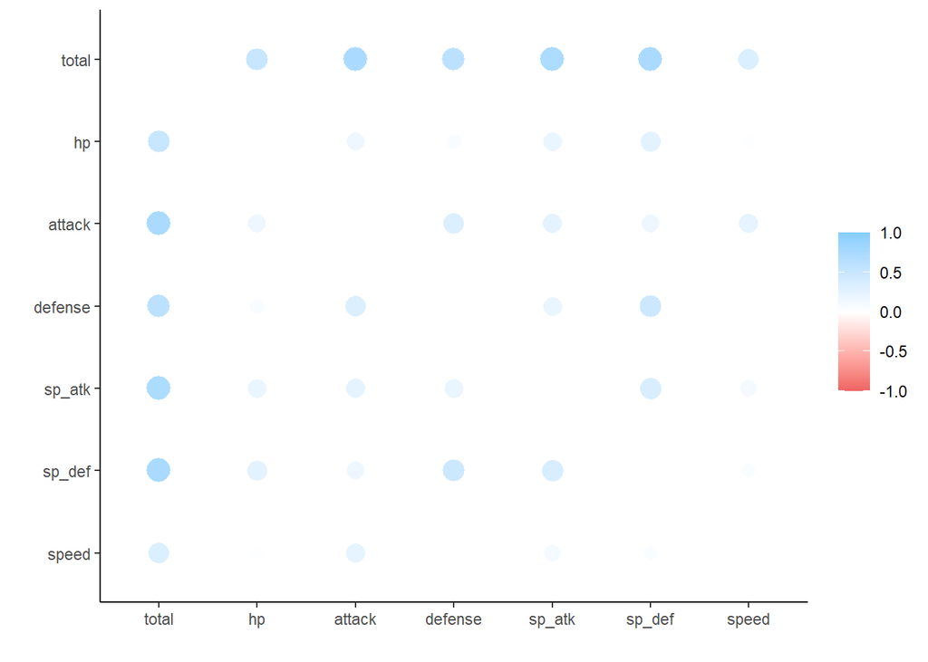

```r
rplot(poke_corrlate)
```

The relationships between these variables makes sense to me. It is obvious that ‘total’ has relationships with the other variables since total represents a combination of the other variables as one value. Similar things can be said for the other variables and the values combined to get their values. Long story short, as one increases, the other(s) increase too.

Question 3.) Decision tree

```r
poke_tree <- decision_tree() %>%
  set_engine("rpart")
```

```r
class_poke_tree <- poke_tree %>%
  set_mode("classification")
```

```r
class_poke_tree_wf <- workflow() %>%
  add_model(class_poke_tree %>% set_args(cost_complexity = tune())) %>%
  add_formula(type_1 ~ legendary + generation + sp_atk + attack + speed + defense + hp + sp_def)
```

```r
poke_grid <- grid_regular(cost_complexity(range = c(-3, -1)), levels = 10)

tune_res <- tune_grid(class_poke_tree_wf,
  resamples = pokemon_train_5fold,
  grid = poke_grid,
  metrics = metric_set(roc_auc))
```

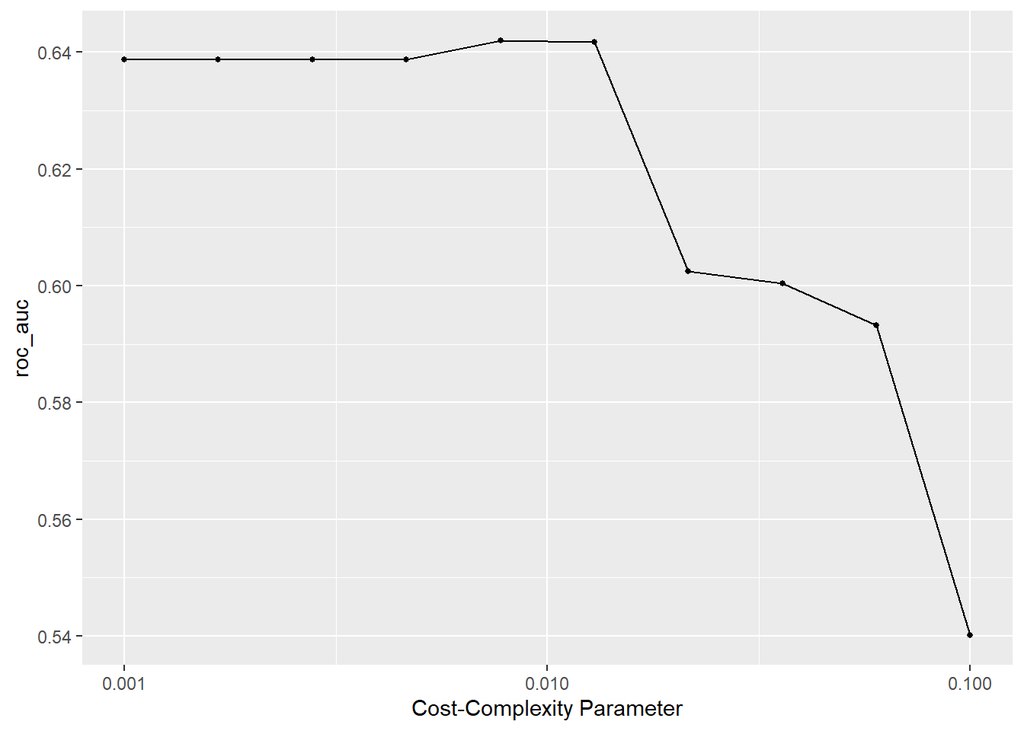

```r
autoplot(tune_res)
```

As we can see, the ROC AUC is best at around 0.01 and smaller values. Model performs worse as complexity penalty increases.

```r
best_complexity <- select_best(tune_res, metric = "roc_auc")

poke_tree_best <- finalize_workflow(class_poke_tree_wf, best_complexity)

poke_tree_best_fit <- fit(poke_tree_best, data = pokemon_train)
```

```r
collect_metrics(tune_res) %>%
  arrange(mean)
```

```
## # A tibble: 10 x 7
##    cost_complexity .metric .estimator  mean     n std_err .config
##              <dbl> <chr>   <chr>      <dbl> <int>   <dbl> <chr>
##  1         0.1     roc_auc hand_till  0.540     5 0.0171  Preprocessor1_Model10
##  2         0.0599  roc_auc hand_till  0.593     5 0.0174  Preprocessor1_Model09
##  3         0.0359  roc_auc hand_till  0.600     5 0.0178  Preprocessor1_Model08
##  4         0.0215  roc_auc hand_till  0.602     5 0.00922 Preprocessor1_Model07
##  5         0.001   roc_auc hand_till  0.639     5 0.0208  Preprocessor1_Model01
##  6         0.00167 roc_auc hand_till  0.639     5 0.0208  Preprocessor1_Model02
##  7         0.00278 roc_auc hand_till  0.639     5 0.0208  Preprocessor1_Model03
##  8         0.00464 roc_auc hand_till  0.639     5 0.0208  Preprocessor1_Model04
##  9         0.0129  roc_auc hand_till  0.642     5 0.0135  Preprocessor1_Model06
## 10         0.00774 roc_auc hand_till  0.642     5 0.0204  Preprocessor1_Model05
```

```r
best_complexity
```

```
## # A tibble: 1 x 2
##   cost_complexity .config
##             <dbl> <chr>
## 1         0.00774 Preprocessor1_Model05
```

As we can see, the ROC_AUC of our best performing model was: 0.6419693 . This occurs with a cost complexity of 0.007742637 .

Question 5.) Visual of best fitted model.

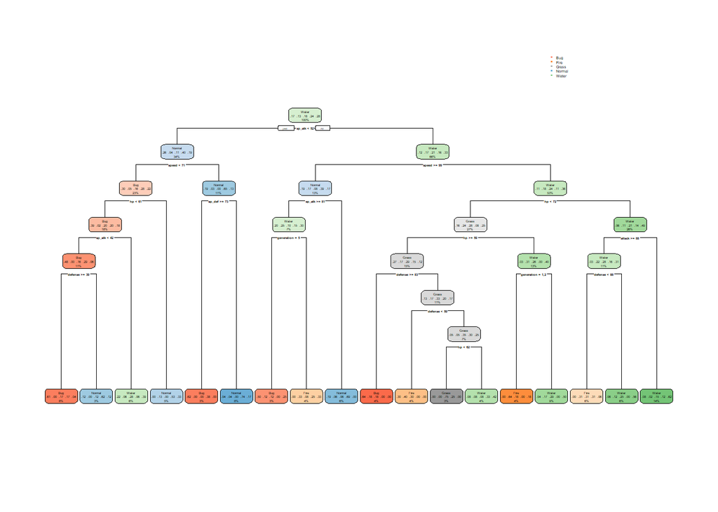

```r
poke_tree_best_fit %>%
  extract_fit_engine() %>%
  rpart.plot()
```

```r
library(ranger)
```

Tuning Parameters: a.) trees = # number of trees for the model b.) mtry = # of variables to be sampled c.) min_n = minimum # of points in a tree in order for the tree to be split further

```r
bagging <- rand_forest(mtry = tune(), trees = tune(), min_n = tune())%>%
  set_engine("ranger", importance = "impurity") %>%
  set_mode("classification")
```

```r
poke_rf_wf <- workflow() %>%
  add_model(bagging) %>%
  add_formula(type_1 ~ legendary + generation + sp_atk + attack + speed + defense + hp + sp_def)
```

regular grid with 8 levels…

```r
poke_regular_grid <- grid_regular(mtry(range = c(0,7)), trees(range = c(0,300)), min_n(range = c(0,10)), levels = 8)
```

A model of mtry: 8 would be a model with 8 randomly sampled variables.

Question 6.)

```r
tune_res_2 <- tune_grid(poke_rf_wf,
  resamples = pokemon_train_5fold,
  grid = poke_regular_grid,
  metrics = metric_set(roc_auc))
```

[output not shown]

[output not shown]

[output not shown]

[output not shown]

[output not shown]

[output not shown]

[output not shown]

[output not shown]

[output not shown]

[output not shown]

[output not shown]

[output not shown]

[output not shown]

[output not shown]

[output not shown]

[output not shown]

[output not shown]

[output not shown]

[output not shown]

[output not shown]

[output not shown]

[output not shown]

[output not shown]

[output not shown]

[output not shown]

[output not shown]

[output not shown]

[output not shown]

[output not shown]

[output not shown]

[output not shown]

[output not shown]

[output not shown]

[output not shown]

[output not shown]

[output not shown]

[output not shown]

[output not shown]

[output not shown]

[output not shown]

[output not shown]

[output not shown]

[output not shown]

[output not shown]

[output not shown]

[output not shown]

[output not shown]

[output not shown]

[output not shown]

[output not shown]

[output not shown]

[output not shown]

[output not shown]

[output not shown]

[output not shown]

[output not shown]

[output not shown]

[output not shown]

[output not shown]

[output not shown]

[output not shown]

[output not shown]

[output not shown]

[output not shown]

[output not shown]

[output not shown]

[output not shown]

[output not shown]

[output not shown]

[output not shown]

[output not shown]

[output not shown]

[output not shown]

[output not shown]

[output not shown]

[output not shown]

[output not shown]

[output not shown]

[output not shown]

[output not shown]

[output not shown]

[output not shown]

[output not shown]

[output not shown]

[output not shown]

[output not shown]

[output not shown]

[output not shown]

[output not shown]

[output not shown]

[output not shown]

[output not shown]

[output not shown]

[output not shown]

[output not shown]

[output not shown]

[output not shown]

[output not shown]

[output not shown]

[output not shown]

[output not shown]

[output not shown]

[output not shown]

[output not shown]

[output not shown]

[output not shown]

[output not shown]

[output not shown]

[output not shown]

[output not shown]

[output not shown]

[output not shown]

[output not shown]

[output not shown]

[output not shown]

[output not shown]

[output not shown]

[output not shown]

[output not shown]

[output not shown]

[output not shown]

[output not shown]

[output not shown]

[output not shown]

[output not shown]

[output not shown]

[output not shown]

[output not shown]

[output not shown]

[output not shown]

[output not shown]

[output not shown]

[output not shown]

[output not shown]

[output not shown]

[output not shown]

[output not shown]

[output not shown]

[output not shown]

[output not shown]

[output not shown]

[output not shown]

[output not shown]

[output not shown]

[output not shown]

[output not shown]

[output not shown]

[output not shown]

[output not shown]

[output not shown]

[output not shown]

[output not shown]

[output not shown]

[output not shown]

[output not shown]

[output not shown]

[output not shown]

[output not shown]

[output not shown]

[output not shown]

[output not shown]

[output not shown]

[output not shown]

[output not shown]

[output not shown]

[output not shown]

[output not shown]

[output not shown]

[output not shown]

[output not shown]

[output not shown]

[output not shown]

[output not shown]

[output not shown]

[output not shown]

[output not shown]

[output not shown]

[output not shown]

[output not shown]

[output not shown]

[output not shown]

[output not shown]

[output not shown]

[output not shown]

[output not shown]

[output not shown]

[output not shown]

[output not shown]

[output not shown]

[output not shown]

[output not shown]

[output not shown]

[output not shown]

[output not shown]

[output not shown]

[output not shown]

[output not shown]

[output not shown]

[output not shown]

[output not shown]

[output not shown]

[output not shown]

[output not shown]

[output not shown]

[output not shown]

[output not shown]

[output not shown]

[output not shown]

[output not shown]

[output not shown]

[output not shown]

[output not shown]

[output not shown]

[output not shown]

[output not shown]

[output not shown]

[output not shown]

[output not shown]

[output not shown]

[output not shown]

[output not shown]

[output not shown]

[output not shown]

[output not shown]

[output not shown]

[output not shown]

[output not shown]

[output not shown]

[output not shown]

[output not shown]

[output not shown]

[output not shown]

[output not shown]

[output not shown]

[output not shown]

[output not shown]

[output not shown]

[output not shown]

[output not shown]

[output not shown]

[output not shown]

[output not shown]

[output not shown]

[output not shown]

[output not shown]

[output not shown]

[output not shown]

[output not shown]

[output not shown]

[output not shown]

[output not shown]

[output not shown]

[output not shown]

[output not shown]

[output not shown]

[output not shown]

[output not shown]

[output not shown]

[output not shown]

[output not shown]

[output not shown]

[output not shown]

[output not shown]

[output not shown]

[output not shown]

[output not shown]

[output not shown]

[output not shown]

[output not shown]

[output not shown]

[output not shown]

[output not shown]

[output not shown]

[output not shown]

[output not shown]

[output not shown]

[output not shown]

[output not shown]

[output not shown]

[output not shown]

[output not shown]

[output not shown]

[output not shown]

[output not shown]

[output not shown]

[output not shown]

[output not shown]

[output not shown]

[output not shown]

[output not shown]

[output not shown]

[output not shown]

[output not shown]

[output not shown]

[output not shown]

[output not shown]

[output not shown]

[output not shown]

[output not shown]

[output not shown]

[output not shown]

[output not shown]

[output not shown]

[output not shown]

[output not shown]

[output not shown]

[output not shown]

[output not shown]

[output not shown]

[output not shown]

[output not shown]

[output not shown]

[output not shown]

[output not shown]

[output not shown]

[output not shown]

[output not shown]

[output not shown]

[output not shown]

[output not shown]

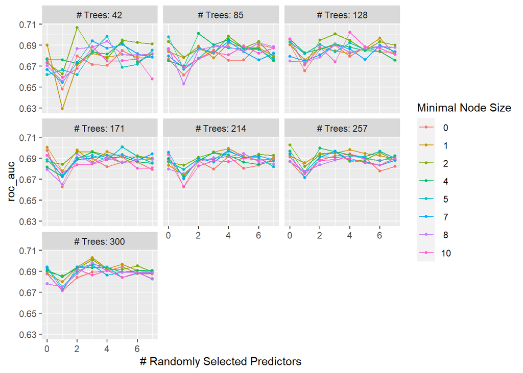

```r
autoplot(tune_res_2)
```

7.) Finding roc_auc of our best model.

```r
best_tree <- select_best(tune_res_2, metric = "roc_auc")

best_tree
```

```
## # A tibble: 1 x 4
##    mtry trees min_n .config
##   <int> <int> <int> <chr>
## 1     2    42     2 Preprocessor1_Model139
```

```r
collect_metrics(tune_res_2) %>%
  arrange(mean)
```

```
## # A tibble: 448 x 9
##     mtry trees min_n .metric .estimator  mean     n std_err .config
##    <int> <int> <int> <chr>   <chr>      <dbl> <int>   <dbl> <chr>
##  1     1    42     1 roc_auc hand_till  0.629     5 0.0292  Preprocessor1_Model~
##  2     1    42     0 roc_auc hand_till  0.648     5 0.0194  Preprocessor1_Model~
##  3     1    85     8 roc_auc hand_till  0.653     5 0.0211  Preprocessor1_Model~
##  4     1    42     7 roc_auc hand_till  0.654     5 0.0236  Preprocessor1_Model~
##  5     1    42     8 roc_auc hand_till  0.655     5 0.0194  Preprocessor1_Model~
##  6     7    42    10 roc_auc hand_till  0.658     5 0.0129  Preprocessor1_Model~
##  7     1    42    10 roc_auc hand_till  0.659     5 0.0159  Preprocessor1_Model~
##  8     1    85     0 roc_auc hand_till  0.662     5 0.0176  Preprocessor1_Model~
##  9     0    42     5 roc_auc hand_till  0.662     5 0.0164  Preprocessor1_Model~
## 10     2    42     5 roc_auc hand_till  0.662     5 0.00860 Preprocessor1_Model~
## # ... with 438 more rows
```

The roc_auc of our best model is: 0.7067818. parameters being…

```r
bagging_final <- rand_forest(mtry = 3, trees = 128, min_n = 5) %>%
  set_engine("ranger", importance = "impurity") %>%
  set_mode("classification")
```

```r
final_fit <- fit(bagging_final, type_1 ~ legendary + generation + sp_atk + attack + speed + defense + hp + sp_def, data = pokemon_train)
```

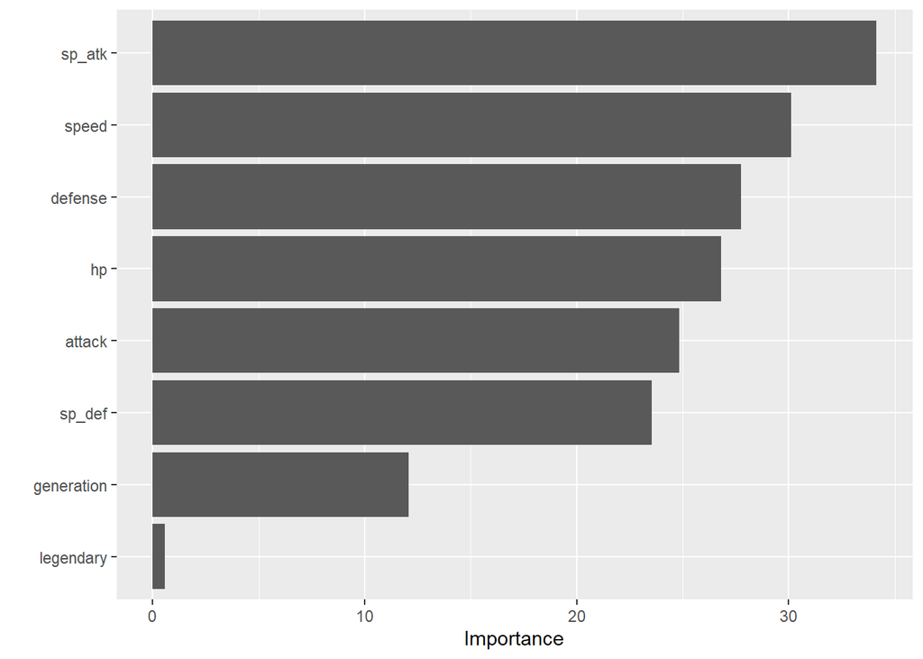

```r
vip(final_fit)
```

According to this, sp_attack and speed are the most important variables while legendary is least important.

This is about what I expected because I know the generation and legendary would have little to no importance.

8.) boosted tree workflow and model

```r
boost_spec <- boost_tree(trees = tune()) %>%
  set_engine("xgboost") %>%
  set_mode("classification")
```

```r
poke_rf_wf2 <- workflow() %>%
  add_model(boost_spec) %>%
  add_formula(type_1 ~ legendary + generation + sp_atk + attack + speed + defense + hp + sp_def)
```

```r
poke_regular_grid2 <- grid_regular(trees(range = c(10,2000)), levels = 10)
```

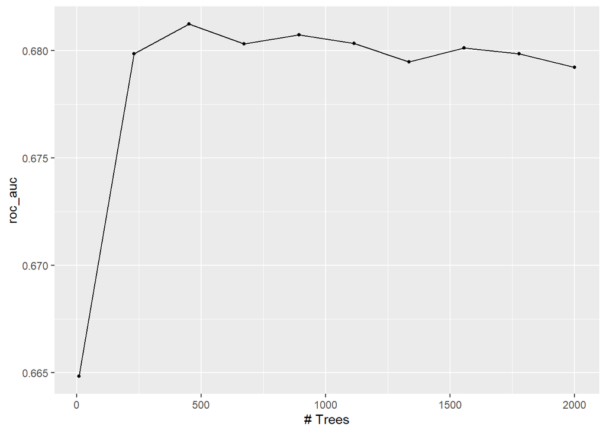

```r
tune_res_3 <- tune_grid(poke_rf_wf2,
  resamples = pokemon_train_5fold,
  grid = poke_regular_grid2,
  metrics = metric_set(roc_auc))

autoplot(tune_res_3)
```

As we can see, the more trees the better to an extent. It peaks at around 450 trees visually from the graph.

```r
best_model <- select_best(tune_res_3, metric = "roc_auc")

best_model
```

```
## # A tibble: 1 x 2
##   trees .config
##   <int> <chr>
## 1   452 Preprocessor1_Model03
```

```r
collect_metrics(tune_res_3) %>%
  arrange(mean)
```

```
## # A tibble: 10 x 7
##    trees .metric .estimator  mean     n std_err .config
##    <int> <chr>   <chr>      <dbl> <int>   <dbl> <chr>
##  1    10 roc_auc hand_till  0.665     5  0.0144 Preprocessor1_Model01
##  2  2000 roc_auc hand_till  0.679     5  0.0167 Preprocessor1_Model10
##  3  1336 roc_auc hand_till  0.679     5  0.0172 Preprocessor1_Model07
##  4   231 roc_auc hand_till  0.680     5  0.0190 Preprocessor1_Model02
##  5  1778 roc_auc hand_till  0.680     5  0.0165 Preprocessor1_Model09
##  6  1557 roc_auc hand_till  0.680     5  0.0166 Preprocessor1_Model08
##  7   673 roc_auc hand_till  0.680     5  0.0165 Preprocessor1_Model04
##  8  1115 roc_auc hand_till  0.680     5  0.0162 Preprocessor1_Model06
##  9   894 roc_auc hand_till  0.681     5  0.0166 Preprocessor1_Model05
## 10   452 roc_auc hand_till  0.681     5  0.0175 Preprocessor1_Model03
```

The roc auc of our best model selection is 0.6812453. This is the model with 452 trees.

10.) So our three roc auc values are…

pruned tree model = 0.6419693 random forest model = 0.7067818 boosted tree model = 0.6812453

And from here it is easy to see that our random forest model is the best to choose from.

finalizing the workflow…

```r
final_wkflow <- finalize_workflow(poke_rf_wf, best_tree)

best_overall_model <- fit(final_wkflow, data = pokemon_train)
```

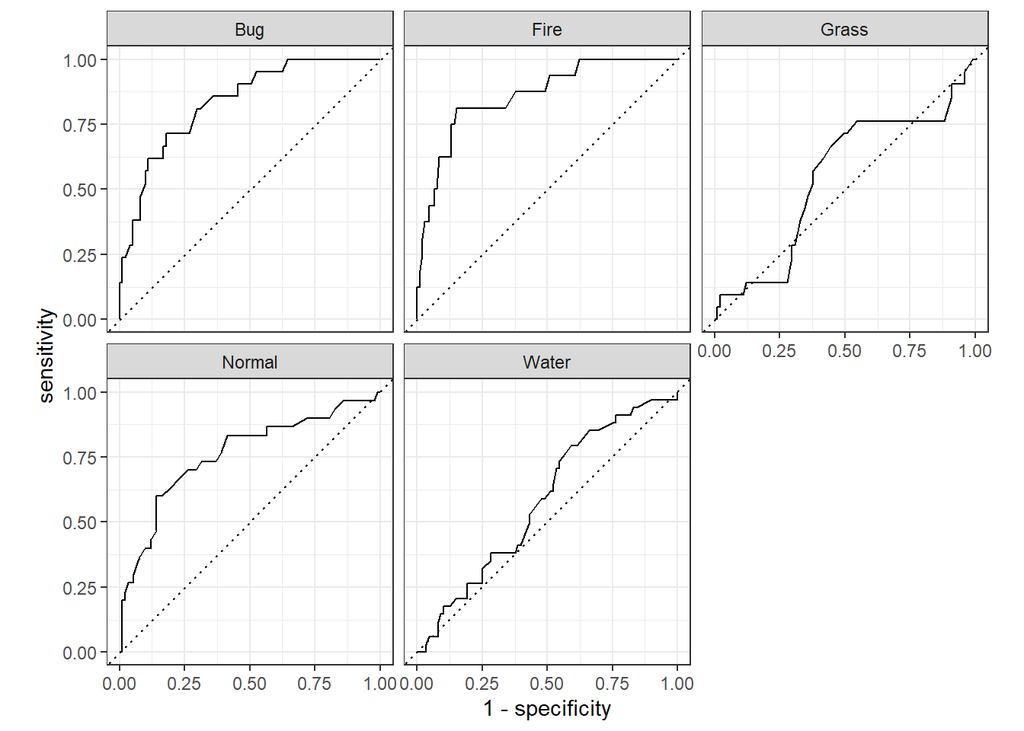

```r
last_fit <- augment(best_overall_model, new_data = pokemon_test)%>%
  roc_curve(truth = type_1, .pred_Bug, .pred_Fire, .pred_Grass, .pred_Normal, .pred_Water)


autoplot(last_fit, type = 'heatmap')
```

```r
last_fit_2 <- augment(best_overall_model, new_data = pokemon_test)%>%
  roc_auc(truth = type_1, .pred_Bug, .pred_Fire, .pred_Grass, .pred_Normal, .pred_Water)

last_fit_2
```

```
## # A tibble: 1 x 3
##   .metric .estimator .estimate
##   <chr>   <chr>          <dbl>
## 1 roc_auc hand_till      0.722
```